# R Módulo IV: Estadística

MIDE

05/12/2020

En esta sesión haremos algunos ejercicios de temas vistos en el modulo IV sobre temas estadísticos. Los temas que se vieron son más o menos los siguientes:

- Probabilidad
- Concepto de variables aleatorias
- Medidas de tendencia central y dispersión
- Distribuciones de probabilidad
- Pruebas de hipótesis

Para lo que sigue, consideremos un conjunto de datos como ejemplo, en el que podamos aplicar los temas que correspondan. Para este tema, se considerarán los datos que están en el archivo `heart_failure_clinical_records_dataset.csv` que están en el directorio de Dropbox. Estos datos corresponden a pacientes que tienen un infarto, y se toman algunos factores de riesgo y algunos indicadores especializados presentes en dichos pacientes. Estos datos fueron obtenidos de [Kaggle](https://www.kaggle.com/andrewmvd/heart-failure-clinical-data).

# Análisis descriptivo

Primero, leemos los datos.

```r
datos <- read.csv("heart_failure_clinical_records_dataset.csv")
```

Los campos que se tienen de la tabla son los siguientes (tomado del diccionario de datos):

- `age`: age of the patient (years)
- `anaemia`: decrease of red blood cells or hemoglobin (boolean)
- `high blood pressure`: if the patient has hypertension (boolean)
- `creatinine phosphokinase` (CPK): level of the CPK enzyme in the blood (mcg/L)
- `diabetes`: if the patient has diabetes (boolean)
- `ejection fraction`: percentage of blood leaving the heart at each contraction (percentage)
- `platelets`: platelets in the blood (kiloplatelets/mL)
- `sex`: woman or man (binary)
- `serum creatinine`: level of serum creatinine in the blood (mg/dL)
- `serum sodium`: level of serum sodium in the blood (mEq/L)
- `smoking`: if the patient smokes or not (boolean)
- `time`: follow-up period (days)
- `death event`: if the patient deceased during the follow-up period (boolean)

Algunas preguntas que se pueden hacer:

- ¿Qué tipo de variable se tiene en cada caso?
- ¿Cuál es la población asociada cada una de estas variables
- ¿De qué tamaño es la muestra que se tiene?

Cada una de las columnas de la matriz de datos puede considerarse una muestra de una variable aleatoria.

```r
datos$gedad <- factor(ifelse(datos$age <= 40, "joven",
                             ifelse(datos$age <= 60, "adulto", "senil")))
str(datos)
```

```
'data.frame':   299 obs. of  14 variables:
 $ age                     : num  75 55 65 50 65 90 75 60 65 80 ...
 $ anaemia                 : int  0 0 0 1 1 1 1 1 0 1 ...
 $ creatinine_phosphokinase: int  582 7861 146 111 160 47 246 315 157 123 ...
 $ diabetes                : int  0 0 0 0 1 0 0 1 0 0 ...
 $ ejection_fraction       : int  20 38 20 20 20 40 15 60 65 35 ...
 $ high_blood_pressure     : int  1 0 0 0 0 1 0 0 0 1 ...
 $ platelets               : num  265000 263358 162000 210000 327000 ...
 $ serum_creatinine        : num  1.9 1.1 1.3 1.9 2.7 2.1 1.2 1.1 1.5 9.4 ...
 $ serum_sodium            : int  130 136 129 137 116 132 137 131 138 133 ...
 $ sex                     : int  1 1 1 1 0 1 1 1 0 1 ...
 $ smoking                 : int  0 0 1 0 0 1 0 1 0 1 ...
 $ time                    : int  4 6 7 7 8 8 10 10 10 10 ...
 $ DEATH_EVENT             : int  1 1 1 1 1 1 1 1 1 1 ...
 $ gedad                   : Factor w/ 3 levels "adulto","joven",..: 3 1 3 1 3 3 3 1 3 3 ...
```

Podemos calcular la matriz de correlaciones entre las variables (excepto la última, que no es numérica)

```r
R <- cor(datos[,-14]) # calcula la matriz de correlaciones
dim(R)
```

```
[1] 13 13
```

```r
round(R,3)
```

```
                            age anaemia creatinine_phosphokinase diabetes
age                       1.000   0.088                   -0.082   -0.101
anaemia                   0.088   1.000                   -0.191   -0.013
creatinine_phosphokinase -0.082  -0.191                    1.000   -0.010
diabetes                 -0.101  -0.013                   -0.010    1.000
ejection_fraction         0.060   0.032                   -0.044   -0.005
high_blood_pressure       0.093   0.038                   -0.071   -0.013
platelets                -0.052  -0.044                    0.024    0.092
serum_creatinine          0.159   0.052                   -0.016   -0.047
serum_sodium             -0.046   0.042                    0.060   -0.090
sex                       0.065  -0.095                    0.080   -0.158
smoking                   0.019  -0.107                    0.002   -0.147
time                     -0.224  -0.141                   -0.009    0.034
DEATH_EVENT               0.254   0.066                    0.063   -0.002
                         ejection_fraction high_blood_pressure platelets
age                                  0.060               0.093    -0.052
anaemia                              0.032               0.038    -0.044
creatinine_phosphokinase            -0.044              -0.071     0.024
diabetes                            -0.005              -0.013     0.092
ejection_fraction                    1.000               0.024     0.072
high_blood_pressure                  0.024               1.000     0.050
platelets                            0.072               0.050     1.000
serum_creatinine                    -0.011              -0.005    -0.041
serum_sodium                         0.176               0.037     0.062
sex                                 -0.148              -0.105    -0.125
smoking                             -0.067              -0.056     0.028
time                                 0.042              -0.196     0.011
DEATH_EVENT                         -0.269               0.079    -0.049
                         serum_creatinine serum_sodium    sex smoking   time
age                                 0.159       -0.046  0.065   0.019 -0.224
anaemia                             0.052        0.042 -0.095  -0.107 -0.141
creatinine_phosphokinase           -0.016        0.060  0.080   0.002 -0.009
diabetes                           -0.047       -0.090 -0.158  -0.147  0.034
ejection_fraction                  -0.011        0.176 -0.148  -0.067  0.042
high_blood_pressure                -0.005        0.037 -0.105  -0.056 -0.196
platelets                          -0.041        0.062 -0.125   0.028  0.011
serum_creatinine                    1.000       -0.189  0.007  -0.027 -0.149
serum_sodium                       -0.189        1.000 -0.028   0.005  0.088
sex                                 0.007       -0.028  1.000   0.446 -0.016
smoking                            -0.027        0.005  0.446   1.000 -0.023
time                               -0.149        0.088 -0.016  -0.023  1.000
DEATH_EVENT                         0.294       -0.195 -0.004  -0.013 -0.527
                         DEATH_EVENT
age                            0.254
anaemia                        0.066
creatinine_phosphokinase       0.063
diabetes                      -0.002
ejection_fraction             -0.269
high_blood_pressure            0.079
platelets                     -0.049
serum_creatinine               0.294
serum_sodium                  -0.195
sex                           -0.004
smoking                       -0.013
time                          -0.527
DEATH_EVENT                    1.000
```

## Gráficas en estadística, estadísticas sumarias

Primero intentamos familiarizarnos con los datos disponibles. Podemos ver los datos, entender a qué se refieren cada una de las columnas de lo datos, etc.

```r
View(datos) # Para mostrar los datos tipo Excel
str(datos)  # estructura de datos
```

```
'data.frame':   299 obs. of  14 variables:
 $ age                     : num  75 55 65 50 65 90 75 60 65 80 ...
 $ anaemia                 : int  0 0 0 1 1 1 1 1 0 1 ...
 $ creatinine_phosphokinase: int  582 7861 146 111 160 47 246 315 157 123 ...
 $ diabetes                : int  0 0 0 0 1 0 0 1 0 0 ...
 $ ejection_fraction       : int  20 38 20 20 20 40 15 60 65 35 ...
 $ high_blood_pressure     : int  1 0 0 0 0 1 0 0 0 1 ...
 $ platelets               : num  265000 263358 162000 210000 327000 ...
 $ serum_creatinine        : num  1.9 1.1 1.3 1.9 2.7 2.1 1.2 1.1 1.5 9.4 ...
 $ serum_sodium            : int  130 136 129 137 116 132 137 131 138 133 ...
 $ sex                     : int  1 1 1 1 0 1 1 1 0 1 ...
 $ smoking                 : int  0 0 1 0 0 1 0 1 0 1 ...
 $ time                    : int  4 6 7 7 8 8 10 10 10 10 ...
 $ DEATH_EVENT             : int  1 1 1 1 1 1 1 1 1 1 ...
 $ gedad                   : Factor w/ 3 levels "adulto","joven",..: 3 1 3 1 3 3 3 1 3 3 ...
```

```r
summary(datos) # da una idea de la distribución de cada variable
```

```
      age           anaemia       creatinine_phosphokinase    diabetes
 Min.   :40.00   Min.   :0.0000   Min.   :  23.0           Min.   :0.0000
 1st Qu.:51.00   1st Qu.:0.0000   1st Qu.: 116.5           1st Qu.:0.0000
 Median :60.00   Median :0.0000   Median : 250.0           Median :0.0000
 Mean   :60.83   Mean   :0.4314   Mean   : 581.8           Mean   :0.4181
 3rd Qu.:70.00   3rd Qu.:1.0000   3rd Qu.: 582.0           3rd Qu.:1.0000
 Max.   :95.00   Max.   :1.0000   Max.   :7861.0           Max.   :1.0000
 ejection_fraction high_blood_pressure   platelets      serum_creatinine
 Min.   :14.00     Min.   :0.0000      Min.   : 25100   Min.   :0.500
 1st Qu.:30.00     1st Qu.:0.0000      1st Qu.:212500   1st Qu.:0.900
 Median :38.00     Median :0.0000      Median :262000   Median :1.100
 Mean   :38.08     Mean   :0.3512      Mean   :263358   Mean   :1.394
 3rd Qu.:45.00     3rd Qu.:1.0000      3rd Qu.:303500   3rd Qu.:1.400
 Max.   :80.00     Max.   :1.0000      Max.   :850000   Max.   :9.400
  serum_sodium        sex            smoking            time
 Min.   :113.0   Min.   :0.0000   Min.   :0.0000   Min.   :  4.0
 1st Qu.:134.0   1st Qu.:0.0000   1st Qu.:0.0000   1st Qu.: 73.0
 Median :137.0   Median :1.0000   Median :0.0000   Median :115.0
 Mean   :136.6   Mean   :0.6488   Mean   :0.3211   Mean   :130.3
 3rd Qu.:140.0   3rd Qu.:1.0000   3rd Qu.:1.0000   3rd Qu.:203.0
 Max.   :148.0   Max.   :1.0000   Max.   :1.0000   Max.   :285.0
  DEATH_EVENT        gedad
 Min.   :0.0000   adulto:155
 1st Qu.:0.0000   joven :  7
 Median :0.0000   senil :137
 Mean   :0.3211
 3rd Qu.:1.0000
 Max.   :1.0000
```

```r
describe(datos) # de psych
```

```
                         vars   n      mean       sd   median   trimmed
age                         1 299     60.83    11.89     60.0     60.22
anaemia                     2 299      0.43     0.50      0.0      0.41
creatinine_phosphokinase    3 299    581.84   970.29    250.0    365.49
diabetes                    4 299      0.42     0.49      0.0      0.40
ejection_fraction           5 299     38.08    11.83     38.0     37.43
high_blood_pressure         6 299      0.35     0.48      0.0      0.32
platelets                   7 299 263358.03 97804.24 262000.0 256730.09
serum_creatinine            8 299      1.39     1.03      1.1      1.19
serum_sodium                9 299    136.63     4.41    137.0    136.82
sex                        10 299      0.65     0.48      1.0      0.68
smoking                    11 299      0.32     0.47      0.0      0.28
time                       12 299    130.26    77.61    115.0    129.28
DEATH_EVENT                13 299      0.32     0.47      0.0      0.28
gedad*                     14 299      1.94     0.99      1.0      1.93
                              mad     min      max    range  skew kurtosis
age                         14.83    40.0     95.0     55.0  0.42    -0.22
anaemia                      0.00     0.0      1.0      1.0  0.28    -1.93
creatinine_phosphokinase   269.83    23.0   7861.0   7838.0  4.42    24.53
diabetes                     0.00     0.0      1.0      1.0  0.33    -1.90
ejection_fraction           11.86    14.0     80.0     66.0  0.55     0.00
high_blood_pressure          0.00     0.0      1.0      1.0  0.62    -1.62
platelets                65234.40 25100.0 850000.0 824900.0  1.45     6.03
serum_creatinine             0.30     0.5      9.4      8.9  4.41    25.19
serum_sodium                 4.45   113.0    148.0     35.0 -1.04     3.98
sex                          0.00     0.0      1.0      1.0 -0.62    -1.62
smoking                      0.00     0.0      1.0      1.0  0.76    -1.42
time                       105.26     4.0    285.0    281.0  0.13    -1.22
DEATH_EVENT                  0.00     0.0      1.0      1.0  0.76    -1.42
gedad*                       0.00     1.0      3.0      2.0  0.12    -1.97
                              se
age                         0.69
anaemia                     0.03
creatinine_phosphokinase   56.11
diabetes                    0.03
ejection_fraction           0.68
high_blood_pressure         0.03
platelets                5656.17
serum_creatinine            0.06
serum_sodium                0.26
sex                         0.03
smoking                     0.03
time                        4.49
DEATH_EVENT                 0.03
gedad*                      0.06
```

```r
#Para calcular la desviación estándar:
apply(datos[ ,-14],2,sd)
```

```
                     age                  anaemia creatinine_phosphokinase
            1.189481e+01             4.961073e-01             9.702879e+02
                diabetes        ejection_fraction      high_blood_pressure
            4.940671e-01             1.183484e+01             4.781364e-01
               platelets         serum_creatinine             serum_sodium
            9.780424e+04             1.034510e+00             4.412477e+00
                     sex                  smoking                     time
            4.781364e-01             4.676704e-01             7.761421e+01
             DEATH_EVENT
            4.676704e-01
```

Podemos estudiar subpoblaciones, o poblaciones condicionando por alguna variable de interés.

```r
describe(age ~ diabetes, data = datos) # podemos obtener información por grupos
```

```
 Descriptive statistics by group
diabetes: 0
    vars   n  mean    sd median trimmed   mad min max range skew kurtosis   se
age    1 174 61.85 12.72     60   61.34 14.83  40  95    55 0.32    -0.55 0.96
------------------------------------------------------------
diabetes: 1
    vars   n  mean    sd median trimmed   mad min max range skew kurtosis   se
age    1 125 59.42 10.53     60   58.88 10.38  40  94    54 0.46     0.28 0.94
```

```r
describe(anaemia ~ gedad, data = datos) # proporción de personas por grupo de edad
```

```
 Descriptive statistics by group
gedad: adulto
        vars   n mean  sd median trimmed mad min max range skew kurtosis   se
anaemia    1 155 0.43 0.5      0    0.41   0   0   1     1  0.3    -1.92 0.04
------------------------------------------------------------
gedad: joven
        vars n mean   sd median trimmed mad min max range skew kurtosis   se
anaemia    1 7 0.29 0.49      0    0.29   0   0   1     1 0.75     -1.6 0.18
------------------------------------------------------------
gedad: senil
        vars   n mean  sd median trimmed mad min max range skew kurtosis   se
anaemia    1 137 0.45 0.5      0    0.43   0   0   1     1 0.22    -1.97 0.04
```

```r
describe(anaemia + diabetes ~ gedad, data = datos) # se puede hacer para varias variables
```

```
 Descriptive statistics by group
gedad: adulto
         vars   n mean  sd median trimmed mad min max range skew kurtosis   se
anaemia     1 155 0.43 0.5      0    0.41   0   0   1     1 0.30    -1.92 0.04
diabetes    2 155 0.46 0.5      0    0.45   0   0   1     1 0.17    -1.98 0.04
------------------------------------------------------------
gedad: joven
         vars n mean   sd median trimmed mad min max range skew kurtosis   se
anaemia     1 7 0.29 0.49      0    0.29   0   0   1     1 0.75     -1.6 0.18
diabetes    2 7 0.29 0.49      0    0.29   0   0   1     1 0.75     -1.6 0.18
------------------------------------------------------------
gedad: senil
         vars   n mean   sd median trimmed mad min max range skew kurtosis   se
anaemia     1 137 0.45 0.50      0    0.43   0   0   1     1 0.22    -1.97 0.04
diabetes    2 137 0.38 0.49      0    0.35   0   0   1     1 0.49    -1.77 0.04
```

Podemos hacer varios tipos de gráficas, dependiendo de los datos disponibles. Por ejemplo, un histograma

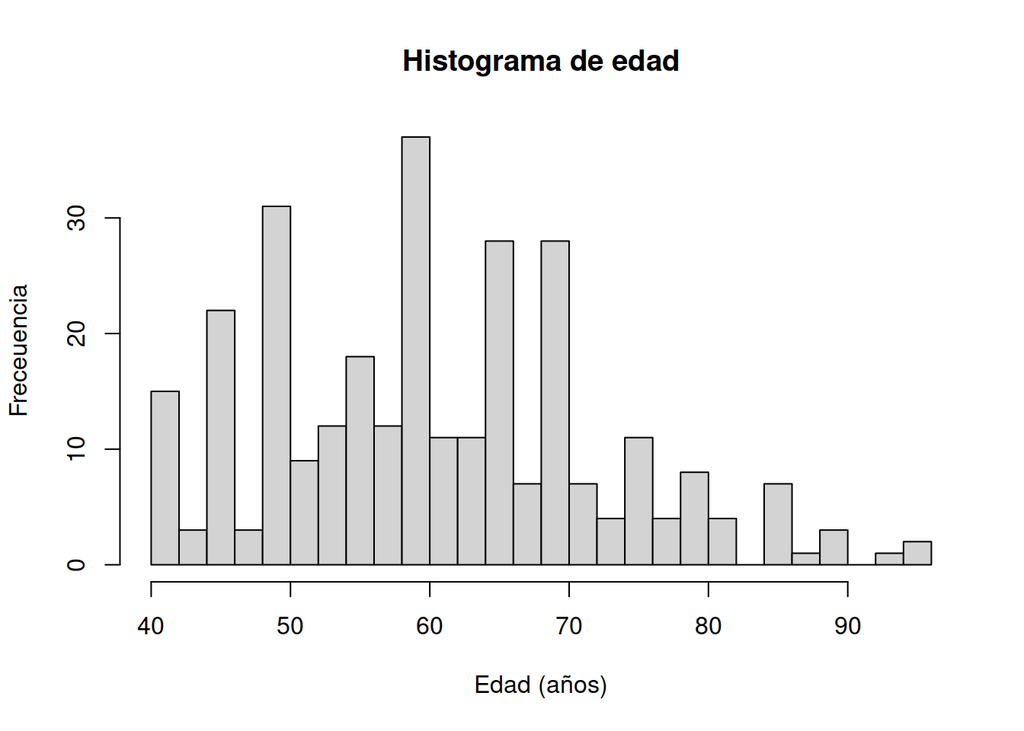

```r
# histograma y densidad
hist(datos$age, breaks = 30,
     main = "Histograma de edad",
     xlab= "Edad (años)",
     ylab = "Freceuencia")
```

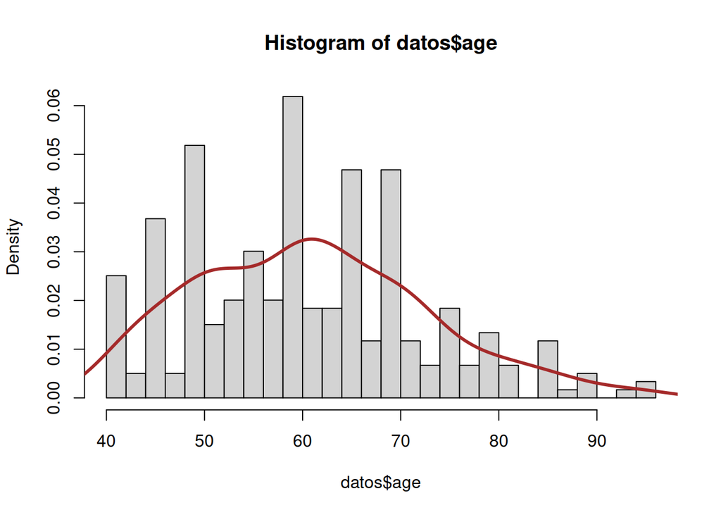

```r
hist(datos$age, breaks = 20, prob=T)
lines(density(datos$age), col = "brown", lwd = 3, lty = 1)
```

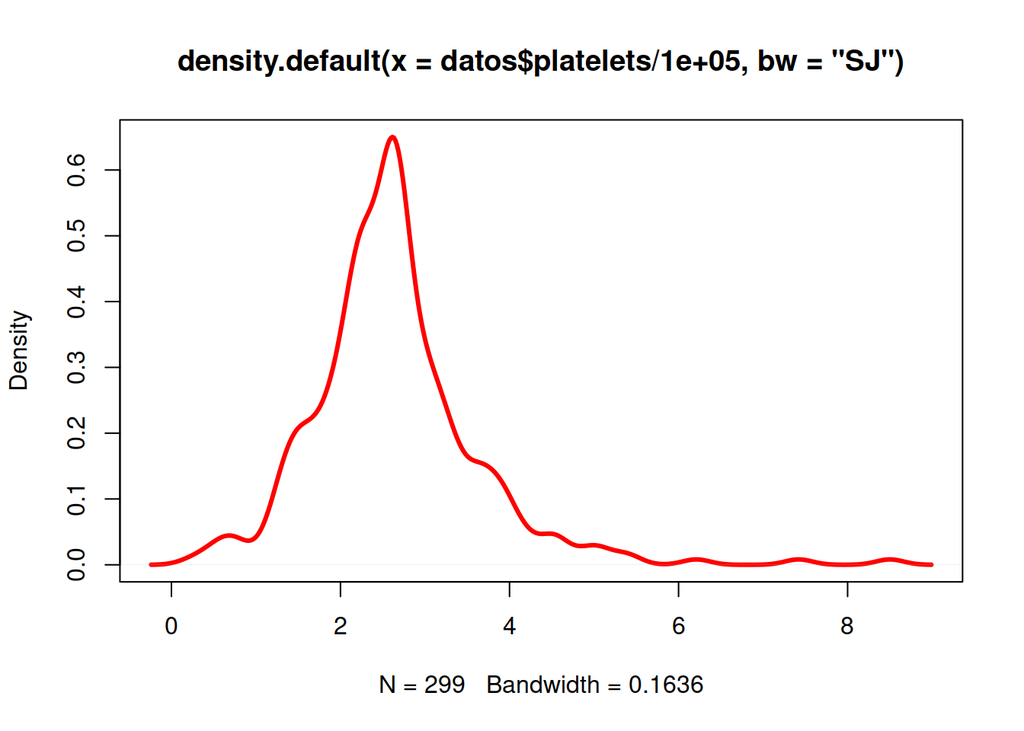

```r
plot(density(datos$platelets/1e5, bw="SJ"), col="red",lwd=3)
```

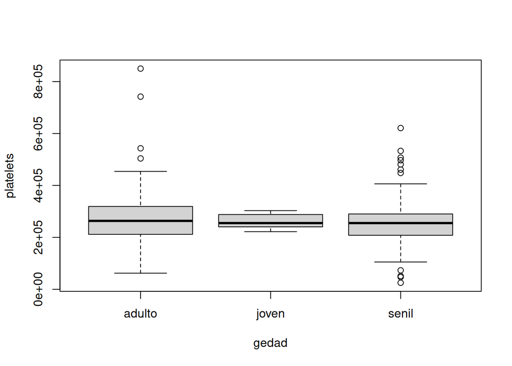

```r
# gráfica de caja (para hacer comparaciones entre subpoblaciones)
boxplot(platelets ~ gedad, data = datos)
```

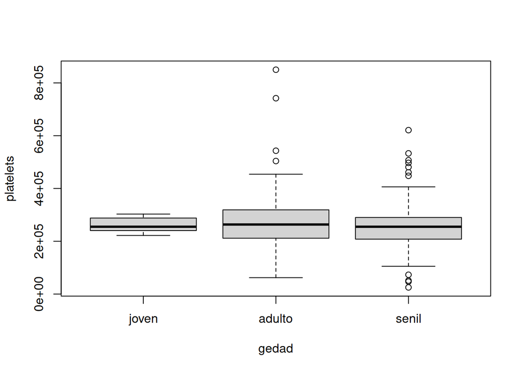

```r
# podemos hacer un factor ordenado
datos$gedad <- factor(datos$gedad, ordered = T, levels= c("joven", "adulto", "senil"))
boxplot(platelets ~ gedad, data = datos)
```

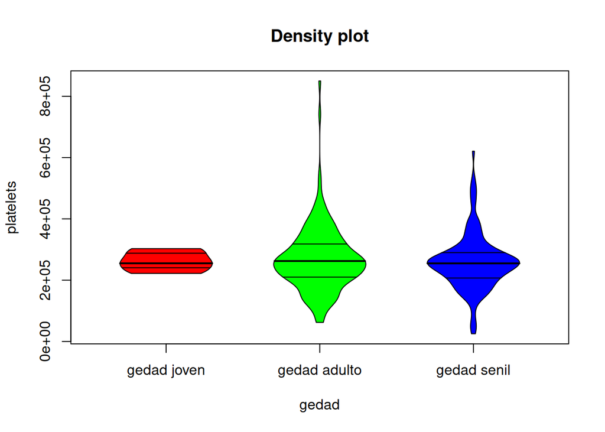

```r
violin(platelets ~ gedad, data = datos, col = rainbow(3)) #Paquete psych
```

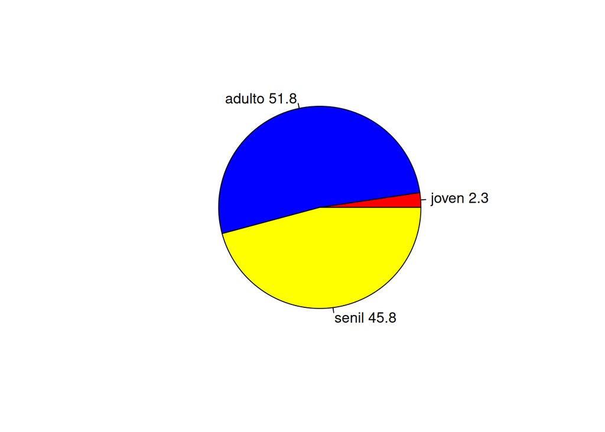

```r
# pie: no recomendado
rebanadas <- table(datos$gedad)
etiquetas <- paste(levels(datos$gedad),round(100*rebanadas/length(datos$gedad),1))
pie(rebanadas, labels = etiquetas, col = c("red","blue","yellow"))
```

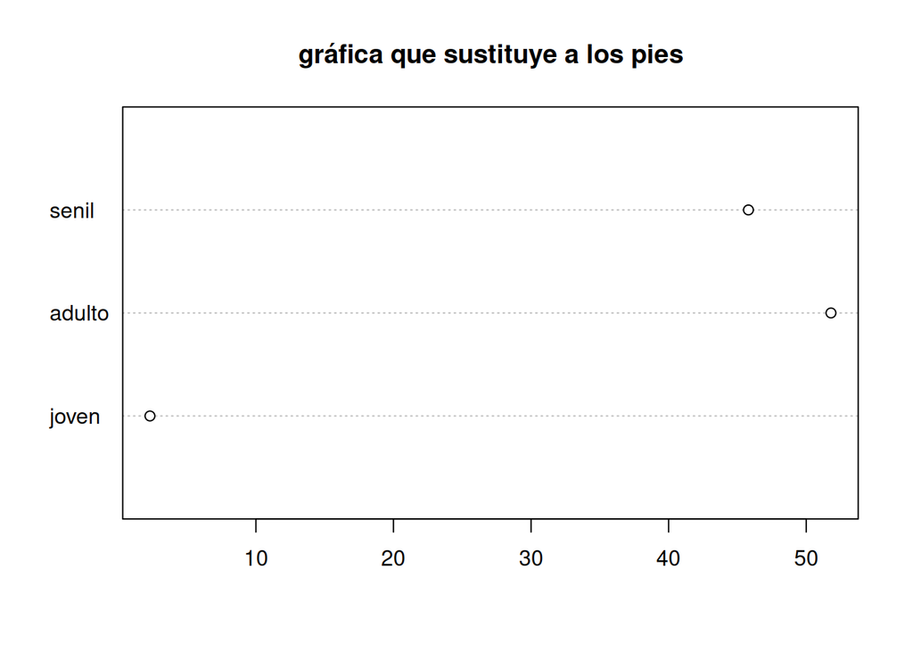

```r
# Un mejor método para graficar proporciones son los dotcharts
dotchart(round(100*rebanadas/length(datos$gedad),1),
         main = "gráfica que sustituye a los pies")
```

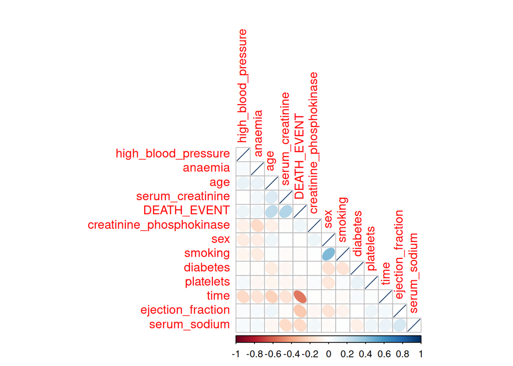

```r
# matriz de correlaciones
library(corrplot)
corrplot(R, method = "ellipse",type = "lower",order = "hclust")
```

[figure not shown]

```r
# Gráfica de telaraña o radar
library(fmsb)
radarchart(datos[,c(1,3,5)],axistype = 1)
```

## Probabilidad, variables aleatorias, Distribuciones discretas y continuas

Podemos generar muestras de prácticamente cualquier variable aleatoria que necesitemos en la práctica. También podemos estimar los parámetros de un modelo, revisar bondad de ajuste de los datos, etc.

```r
# devuelve los índices en la matriz de datos que corresponden a
# diabéticos
diabeticos <- which(datos$diabetes==1)
# calcula la probabilidad de que un diabético tenga menos de 45 años
mean(datos$age[diabeticos] <= 45) # probabilidad
```

```
[1] 0.136
```

```r
# calcula la probabilidad de que un diaético tenga más de 60 años
mean(datos$age[diabeticos] > 60) # probabilidad
```

```
[1] 0.416
```

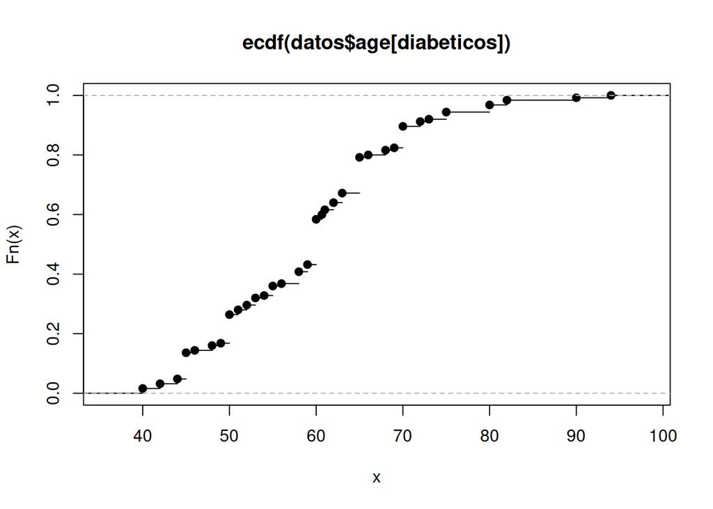

```r
# Distribución de probabilidad emṕirica de la edad de los diabéticos
plot(ecdf(datos$age[diabeticos]))
```

¿Cómo se compara la distribución de plaquetas con una distribución normal? Usamos la función de distribución acumulativa.

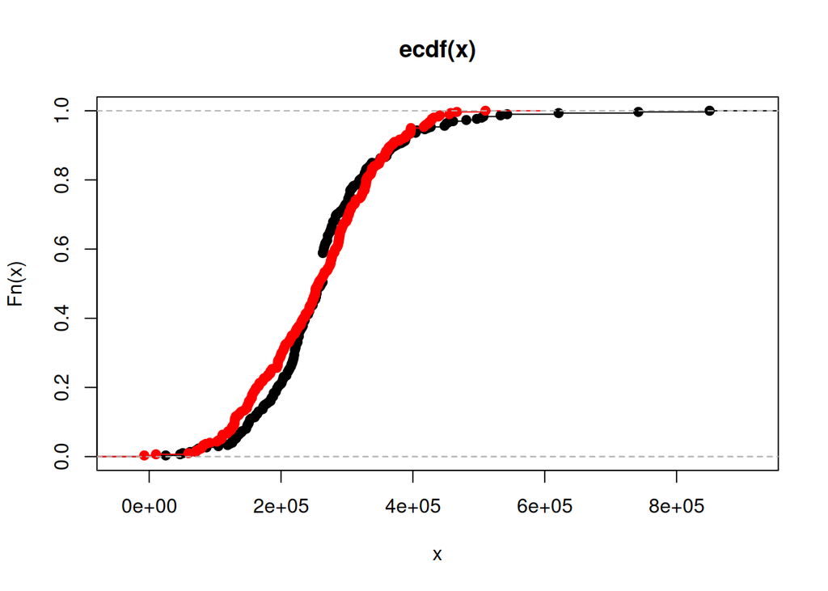

```r
# proporción de observaciones en la muestra que son menores o
# iguales a un valor x: P(X<=x)
plot.ecdf(datos$platelets)

lines(ecdf(rnorm(300, mean=mean(datos$platelets),
                 sd = sd(datos$platelets))), col = "red")
```

```r
# Prueba de Kolmogorov-Smirnov para bondad de ajuste. Prueba la hipótesis F = G vs F != G
ks.test(x = datos$platelets, y = "rnorm", alternative = "two.sided")
```

```
    Asymptotic one-sample Kolmogorov-Smirnov test

data:  datos$platelets
D = 3.5346, p-value < 2.2e-16
alternative hypothesis: two-sided
```

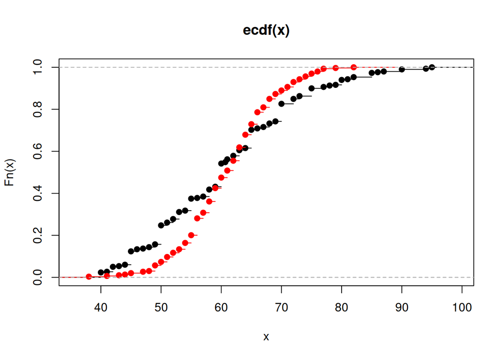

```r
# Se puede hacer la prueba para menor que (less) o mayor que (upper)

plot.ecdf(datos$age)
lines(ecdf(rpois(299, lambda = mean(datos$age))),col = "red")
```

```r
# Prueba de Kolmogorov-Smirnov para bondad de ajuste. Prueba la hipótesis F = G vs F != G
ks.test(x = datos$platelets, y = "rnorm", alternative = "two.sided")
```

```
    Asymptotic one-sample Kolmogorov-Smirnov test

data:  datos$platelets
D = 3.4488, p-value < 2.2e-16
alternative hypothesis: two-sided
```

```r
# Se puede hacer la prueba para menor que (less) o mayor que (upper)
```

Podemos generar observaciones de diferentes distribuciones, continuas y discretas, para diferentes fines:

```r
X <- rpois(1000, lambda = 4)  #Poisson con media 4. La varianza teórica es la misma que la media
# r-nombre : sirve para generar números aleatorios
# q-nombre : sirve para dada una probabilidad, encontrar el quantil
# d-nombre: densidad
# p-nombre: distribución
mean(X)
```

```
[1] 4.028
```

```r
var(X)
```

```
[1] 4.039255
```

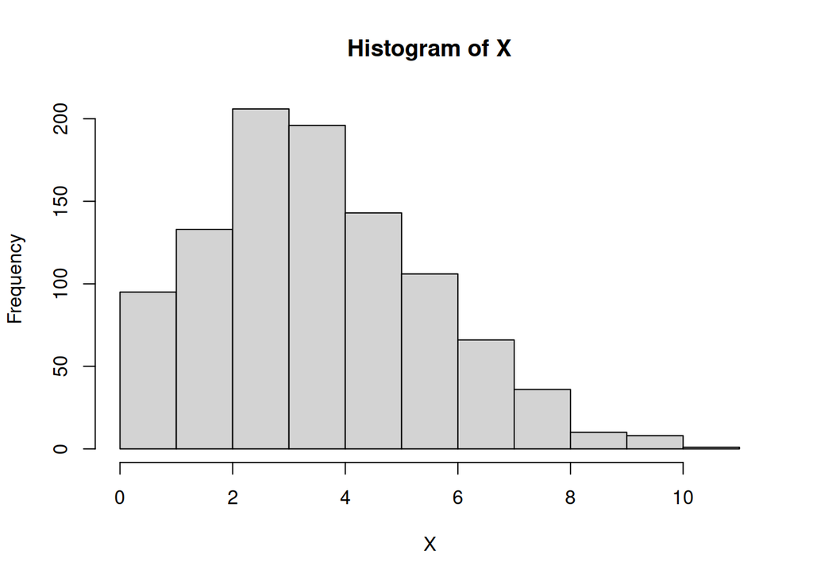

```r
hist(X)
```

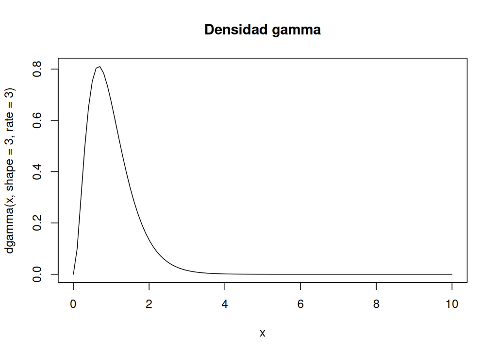

```r
# densidad gamma
curve(dgamma(x, shape = 3, rate = 3), from = 0, to = 10,
      main = "Densidad gamma")
```

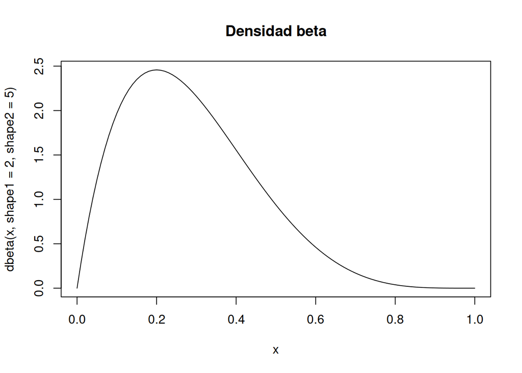

```r
# densidad beta
curve(dbeta(x,shape1 = 2,shape2 = 5), from = 0, to = 1,
      main = "Densidad beta")
```